# My Amazing Article

Other cool stuff

Michael Clark https://m-clark.github.io (CSCAR)https://cscar.research.umich.edu/  
2020-12-07

# Part 1: Basics

## Standard Markdown

All the basic R Markdown stuff holds for text.

#### Emphasis

`*italic* **bold**`

`_italic_ __bold__`

#### Headers

`# Header 1`

`## Header 2`

`### Header 3`

#### Lists

Unordered List:

```
* Item 1
* Item 2
    + Item 2a
    + Item 2b
```

Ordered List:

```
1. Item 1
2. Item 2
3. Item 3
    + Item 3a
    + Item 3b
```

#### Links

Use a plain http address or add a link to a phrase:

```
http://example.com

[linked phrase](http://example.com)
```

#### Images

Images on the web or local files in the same directory:

```
![](http://example.com/logo.png)

![optional caption text](figures/img.png)
```

#### Blockquotes

A friend once said:

```
> It's always better to give
> than to receive.
```

#### Inline Code

```
Here are the numbers `r 1:3`.
```

#### LaTeX Equations

Inline equation:

```
$equation$
```

Display equation:

```
$$ equation $$
```

#### Horizontal Rule / Page Break

Three or more asterisks or dashes:

#### Tables

```
First Header  | Second Header
------------- | -------------
Content Cell  | Content Cell
Content Cell  | Content Cell
Reference Style Links and Images
```

#### Manual Line Breaks

End a line with two or more spaces, or just hit return twice.

```
Roses are red,
Violets are blue.
```

#### Miscellaneous

```
superscript^2^

~~strikethrough~~
```

## Code

Time for code! Again, basic R Markdown is the starting point.

````
```{r}
summary(cars$dist)
summary(cars$speed)
```
````

Inline R Code

```
There were `r nrow(cars)` cars studied
```

Try a chunk yourself! Knit the result!

````
```{r}
x = sample(letters, 5)

x
```
````

Don’t see the code? By default, Distill sets `echo = FALSE`, which means the code will not be shown. Why? The primary goal of the format is *communication of ideas*, not code. Just switch the chunk option to `TRUE`.

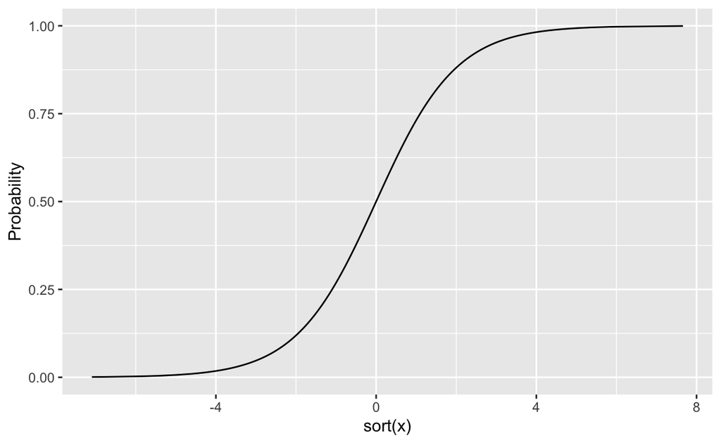

```
library(tidyverse)

x = rlogis(1000)

qplot(sort(x), plogis(sort(x)), ylab = 'Probability', geom = 'line')
```

Already looks nice! By default, highlighting is done using colors optimized for accessibility and color contrast. Many functions are linked to documentation. You can control whether you want that in the YAML options.

## Tables

Easily create a nice table without the fuss!

```
rmarkdown::paged_table(mtcars)
```

|  | mpg | cyl | disp | hp | drat | wt | qsec | vs | am | gear | carb |
| --- | --- | --- | --- | --- | --- | --- | --- | --- | --- | --- | --- |
| Mazda RX4 | 21.0 | 6 | 160.0 | 110 | 3.90 | 2.620 | 16.46 | 0 | 1 | 4 | 4 |
| Mazda RX4 Wag | 21.0 | 6 | 160.0 | 110 | 3.90 | 2.875 | 17.02 | 0 | 1 | 4 | 4 |
| Datsun 710 | 22.8 | 4 | 108.0 | 93 | 3.85 | 2.320 | 18.61 | 1 | 1 | 4 | 1 |
| Hornet 4 Drive | 21.4 | 6 | 258.0 | 110 | 3.08 | 3.215 | 19.44 | 1 | 0 | 3 | 1 |
| Hornet Sportabout | 18.7 | 8 | 360.0 | 175 | 3.15 | 3.440 | 17.02 | 0 | 0 | 3 | 2 |
| Valiant | 18.1 | 6 | 225.0 | 105 | 2.76 | 3.460 | 20.22 | 1 | 0 | 3 | 1 |
| Duster 360 | 14.3 | 8 | 360.0 | 245 | 3.21 | 3.570 | 15.84 | 0 | 0 | 3 | 4 |
| Merc 240D | 24.4 | 4 | 146.7 | 62 | 3.69 | 3.190 | 20.00 | 1 | 0 | 4 | 2 |
| Merc 230 | 22.8 | 4 | 140.8 | 95 | 3.92 | 3.150 | 22.90 | 1 | 0 | 4 | 2 |
| Merc 280 | 19.2 | 6 | 167.6 | 123 | 3.92 | 3.440 | 18.30 | 1 | 0 | 4 | 4 |

[output cut: 22 more lines]

## Visualization

### Distill Layouts

- l-body
- l-body-outset
- l-page
- l-screen

#### l-body

```
library(leaflet)

leaflet(options = leafletOptions(minZoom = 2, maxZoom = 15)) %>%
  setView(lng  = 174.768,
          lat  = -36.852,
          zoom = 10) %>%
  addTiles() %>%
  addMarkers(lng   = 174.768,
             lat   = -36.852,
             popup = "The birthplace of R")
```

[interactive chart not shown]

Note: If you are like me, you will probably never remember these names, so be prepared to look it up.

#### l-body-outset

[interactive chart not shown]

#### l-page

[interactive chart not shown]

#### l-screen

[interactive chart not shown]

Control: Use the fig.asp chunk option to modify the aspect ratio.

[interactive chart not shown]

Figure 1: test figure

Reference figures by chunk name, **as long as they also have a caption**. For example, if the chunk is named ‘aspect-ratio-demo,’ then `\@ref(fig:aspect-ratio-demo)` would reference it. For example, see figure 1.

### Other stuff

Note that for smaller screens, you may not see a difference for the larger sizes.

# Part 2: Miscellaneous Cool Stuff

## Citations

Create a file of your chosen type and point to it in the YAML.

Text/inline code: `Look at this citation- @clark-models, or these [@clark-pds; @clark-iml; @brms].`

Result:

Look at this citation- Clark (2020a), or these (Clark 2020b, 2019; Bürkner 2018).

### Making your work more easily citable

Include in your YAML:

- `author`
- `date`
- `citation_url`

See the bottom of this page!

## Footnotes

Here is a footnote[^1]. They can be clicked or just hovered over.

How to do it:

`Here is a footnote[^footnote]. They can be clicked or just hovered over.` `[^footnote]: Hey! It's a footnote!` $\rightarrow$ *This can be anywhere in the document.*

## Asides

Asides are one of the best features of distill.

You never have to use parentheses again!

Bürkner, Paul-Christian. 2018. “Advanced Bayesian Multilevel Modeling with the R Package brms.” *The R Journal* 10 (1): 395–411. https://doi.org/10.32614/RJ-2018-017.

Clark, Michael. 2019. “Introduction to Machine Learning.” https://m-clark.github.io/introduction-to-machine-learning/.

———. 2020a. “Model Estimation by Example.” https://m-clark.github.io/models-by-example/.

———. 2020b. “Practical Data Science.” https://m-clark.github.io/data-processing-and-visualization/.

[^1]: Hey! It’s a footnote!